# ps0

### 2.2 3.3.1

1.What’s gone wrong with this code? Why are the points not blue?

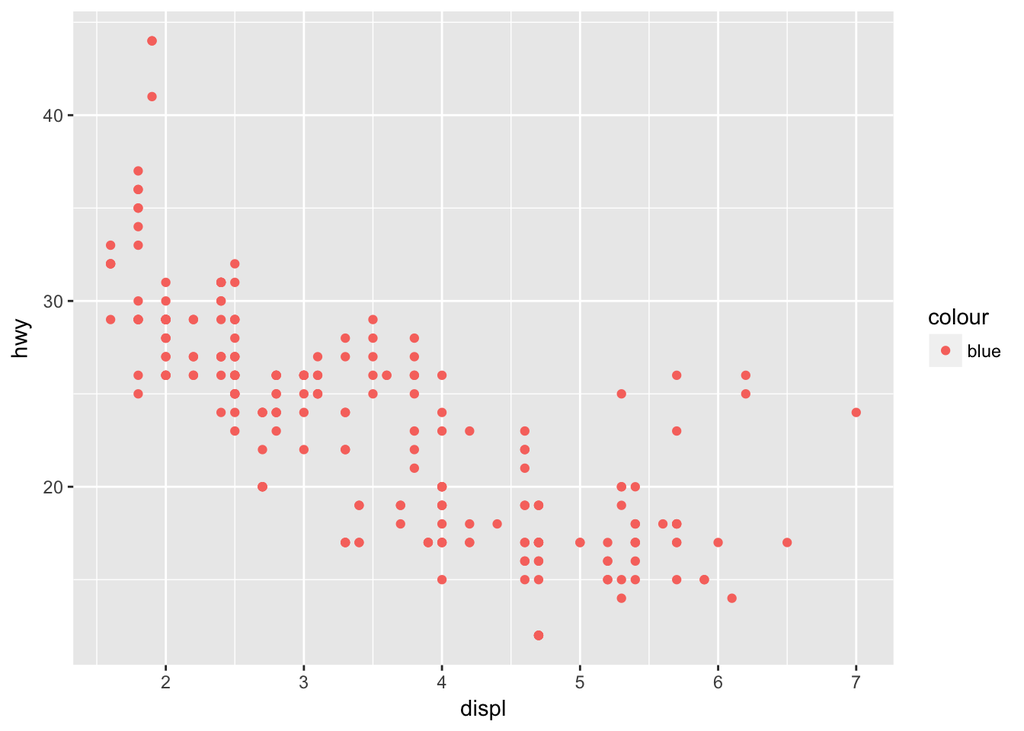

In r, filling a color needs to be outside of aes( ). Because aes specifies the variables we want to plot, by putting the values inside aes(), we generate new variables and legends. The right way should be:

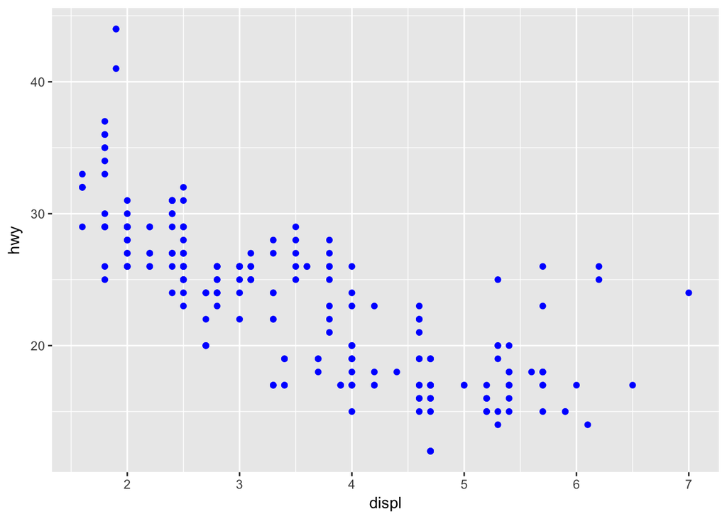

```r
ggplot(data = mpg) +
  geom_point(mapping = aes(x = displ, y = hwy), color="blue")
```

-or:

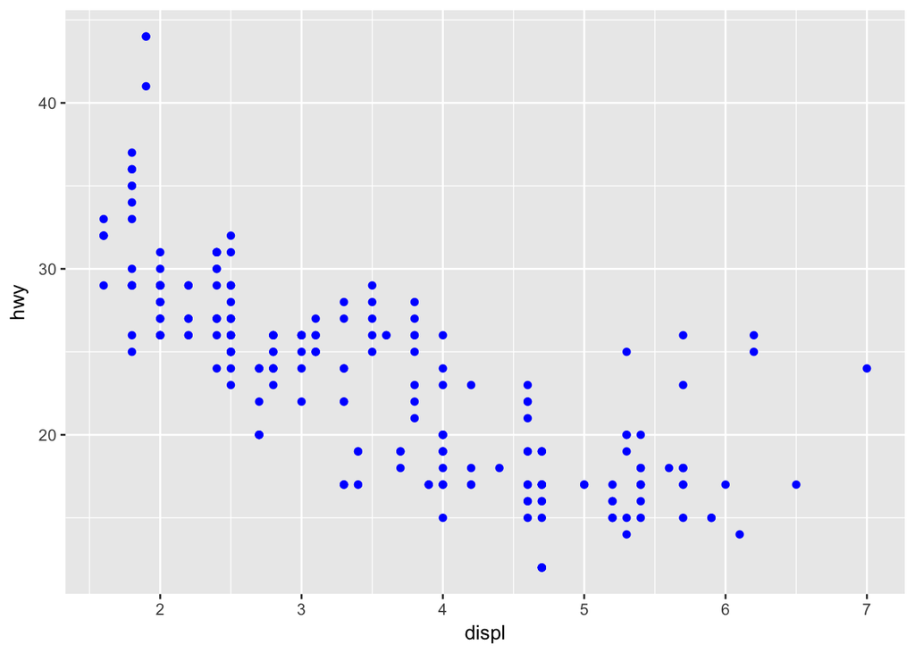

```r
ggplot(data = mpg,aes(x = displ, y = hwy)) +
  geom_point(color="blue")
```

```r
?mpg
sapply(mpg, class)
```

```
## manufacturer        model        displ         year          cyl
##  "character"  "character"    "numeric"    "integer"    "integer"
##        trans          drv          cty          hwy           fl
##  "character"  "character"    "integer"    "integer"  "character"
##        class
##  "character"
```

From print() commend, variable type is shown below the variable. *displ, year, cyl, cty*, and *hwy* are the continuous variables. Variables *manufacturer, model, trans, drv, fl*, and *class* are categorical.

```r
print(mpg)
```

```
## # A tibble: 234 x 11
##    manufacturer      model displ  year   cyl      trans   drv   cty   hwy
##           <chr>      <chr> <dbl> <int> <int>      <chr> <chr> <int> <int>
##  1         audi         a4   1.8  1999     4   auto(l5)     f    18    29
##  2         audi         a4   1.8  1999     4 manual(m5)     f    21    29
##  3         audi         a4   2.0  2008     4 manual(m6)     f    20    31
##  4         audi         a4   2.0  2008     4   auto(av)     f    21    30
##  5         audi         a4   2.8  1999     6   auto(l5)     f    16    26
##  6         audi         a4   2.8  1999     6 manual(m5)     f    18    26
##  7         audi         a4   3.1  2008     6   auto(av)     f    18    27
##  8         audi a4 quattro   1.8  1999     4 manual(m5)     4    18    26
##  9         audi a4 quattro   1.8  1999     4   auto(l5)     4    16    25
## 10         audi a4 quattro   2.0  2008     4 manual(m6)     4    20    28
## # ... with 224 more rows, and 2 more variables: fl <chr>, class <chr>
```

3. **Color Mapping**

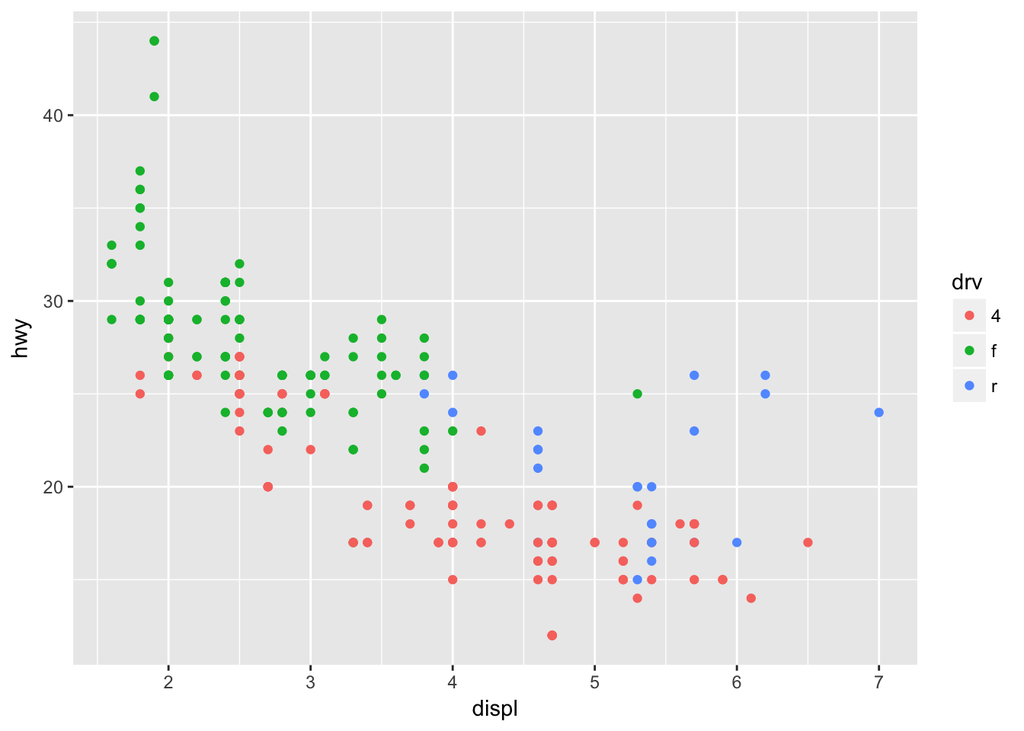

```r
ggplot(data = mpg) +
  geom_point(mapping = aes(x = displ, y = hwy, color=drv)) #discrete var
```

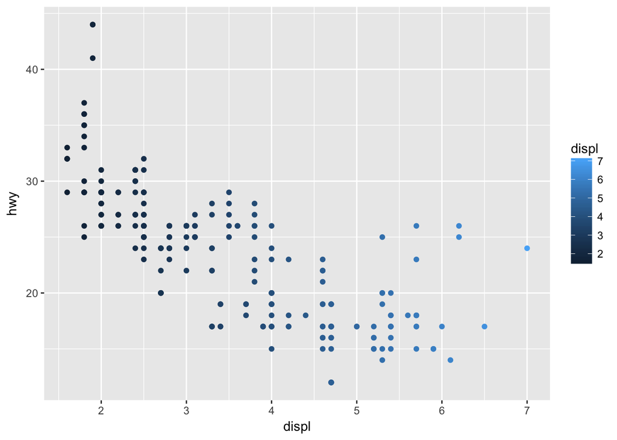

```r
ggplot(data = mpg) +
  geom_point(mapping = aes(x = displ, y = hwy, color=displ)) #continuous var
```

**Size Mapping**

When a **continuos variable** is mapped to size, the size of data points increases gradually when the value of the mapped variable increases. For **categorical variables**, the number of sizes of data points would be the number of categories.

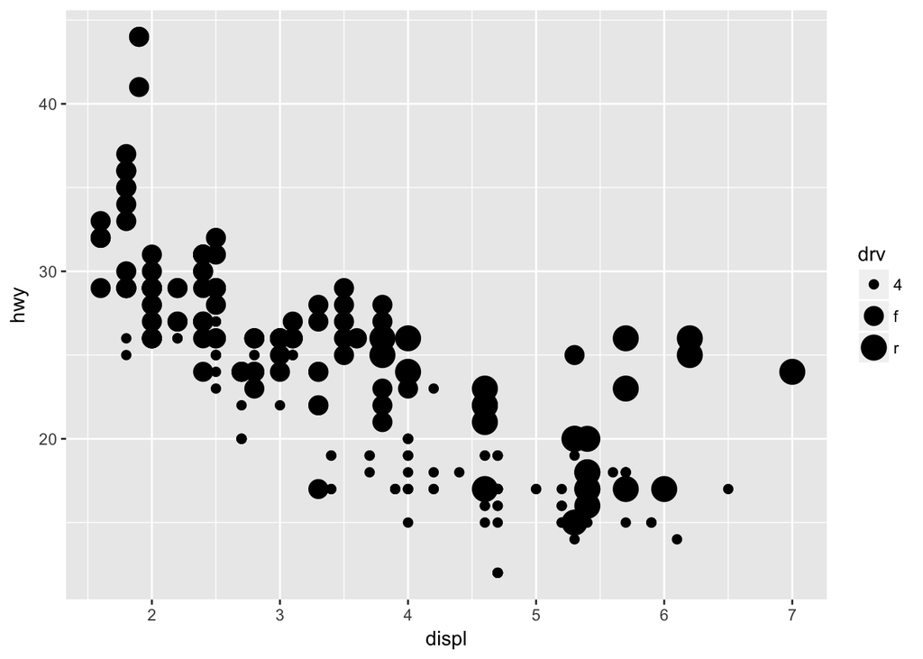

```r
ggplot(data = mpg) +
  geom_point(mapping = aes(x = displ, y = hwy, size=drv))
```

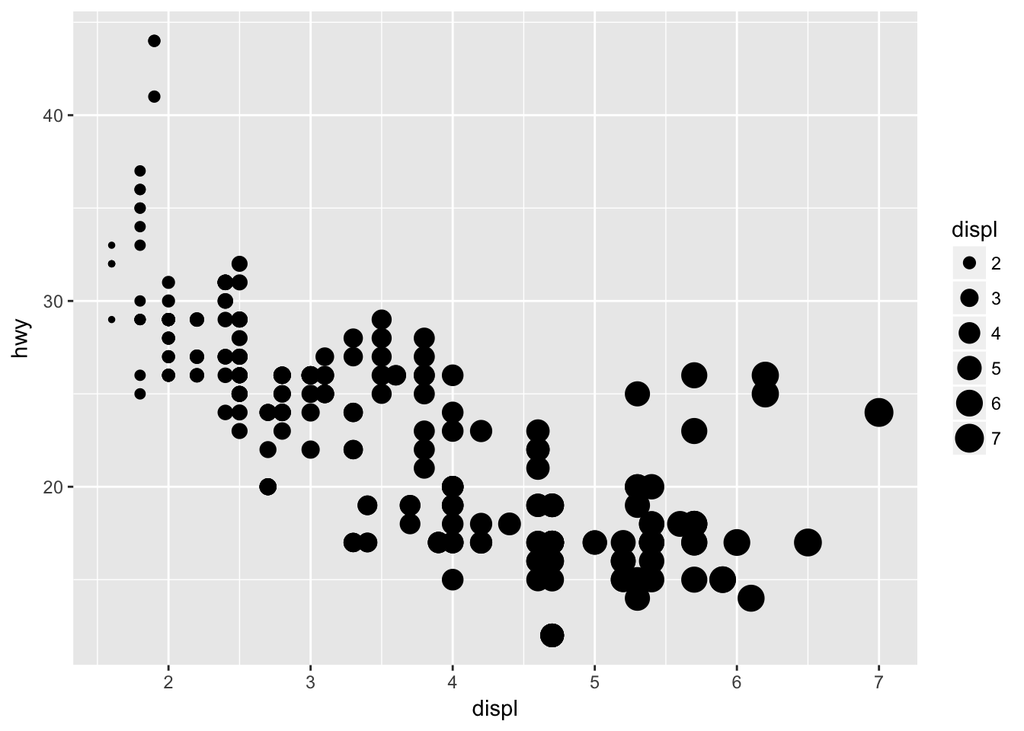

```r
ggplot(data = mpg) +
  geom_point(mapping = aes(x = displ, y = hwy, size=displ))
```

**Shape Mapping**

With a categorical variable, data points are plotted of diffrent shapes according to the value of the categorical variable, whereas a continuous variable cannot be mapped to shape

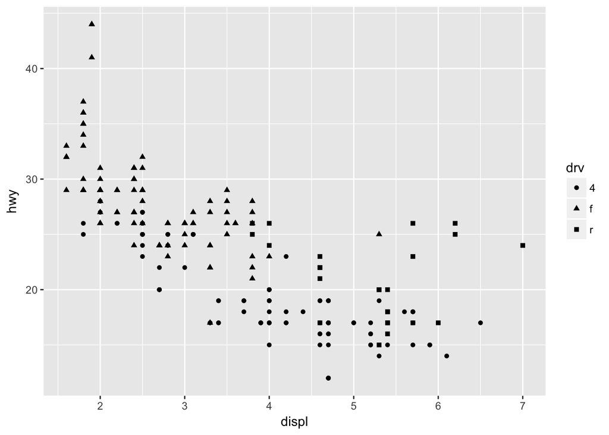

```r
ggplot(data = mpg) +
  geom_point(mapping = aes(x = displ, y = hwy, shape=drv))
```

```r
ggplot(data = mpg) +
  geom_point(mapping = aes(x = displ, y = hwy, shape=displ))
```

```
## Error: A continuous variable can not be mapped to shape
```

4.For discrete variables, all three aethetics are implemented and only one legend is generated which combines color, shape, and size. Data points that have the same value of the mapped variable, have the same shape, color, and size.

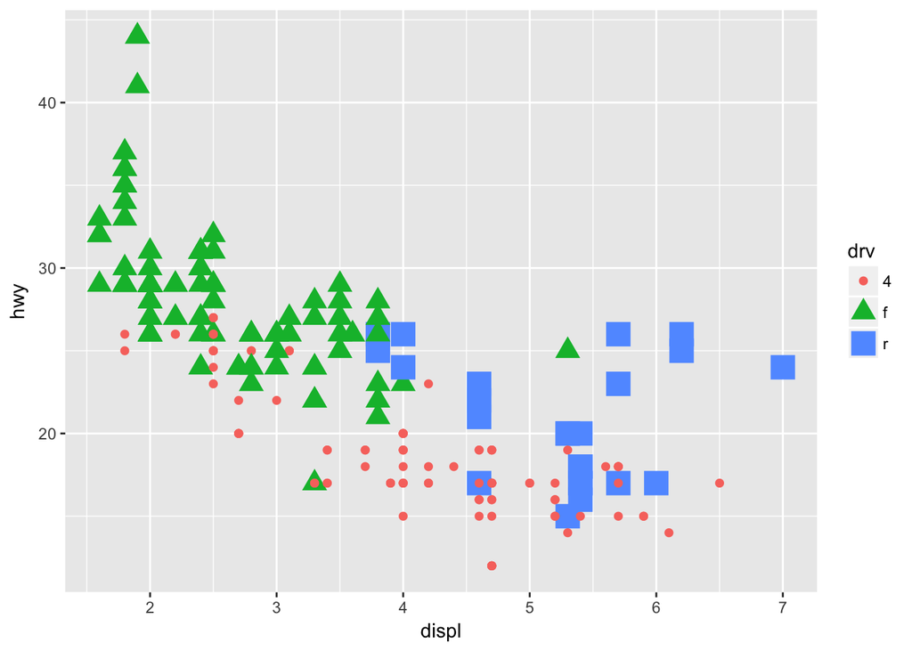

```r
ggplot(data = mpg) +
  geom_point(mapping = aes(x = displ, y = hwy, color=drv, size=drv, shape=drv ))
```

For continuous varibles, only color and size are implemented and there are two legends.

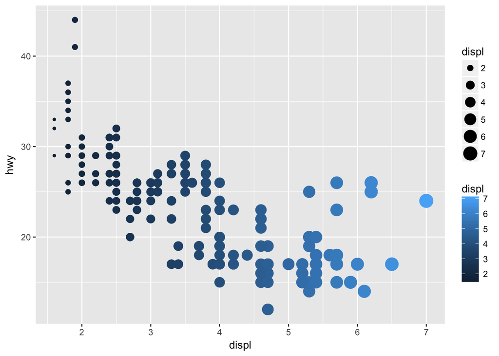

```r
ggplot(data = mpg) +
  geom_point(mapping = aes(x = displ, y = hwy, color=displ, size=displ ))
```

5. A stroke aesthetic controls the border width of shapes 21-25.

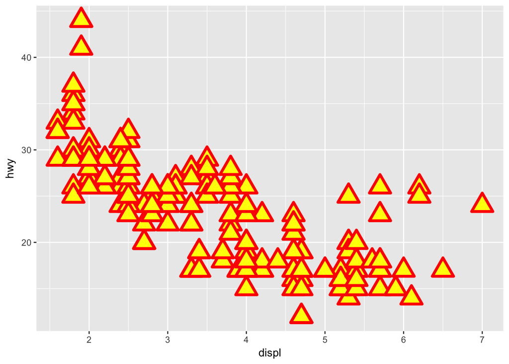

```r
ggplot(data = mpg) +
  geom_point(mapping = aes(x = displ, y = hwy), stroke = 2, shape = 24, size = 6, color="red", fill="yellow")
```

6. R generates a temporary variable which is true is displ < 5 and false if displ > 5).By mapping a aethetic with a threshold, data points with the value True have the color blue, while data points with the value False have the color pink.

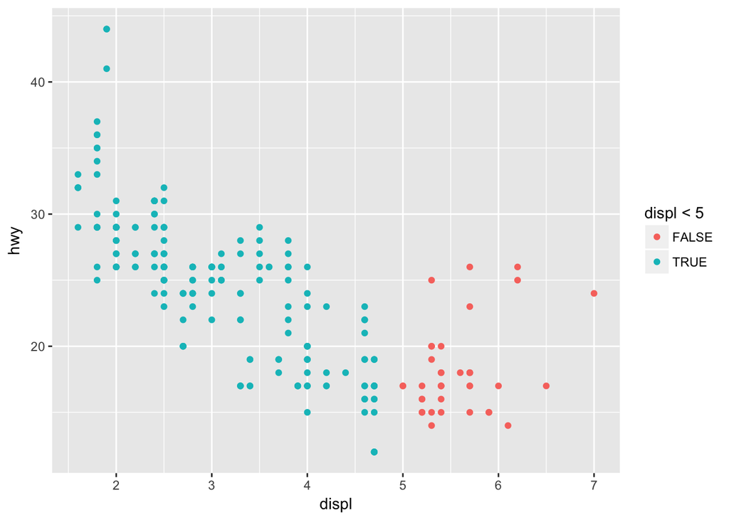

```r
ggplot(data = mpg) +
  geom_point(mapping = aes(x = displ, y = hwy, color=displ < 5))
```

### 2.3 3.5.1

1. R scatterplots data points on seperate facets by each value of variable displ

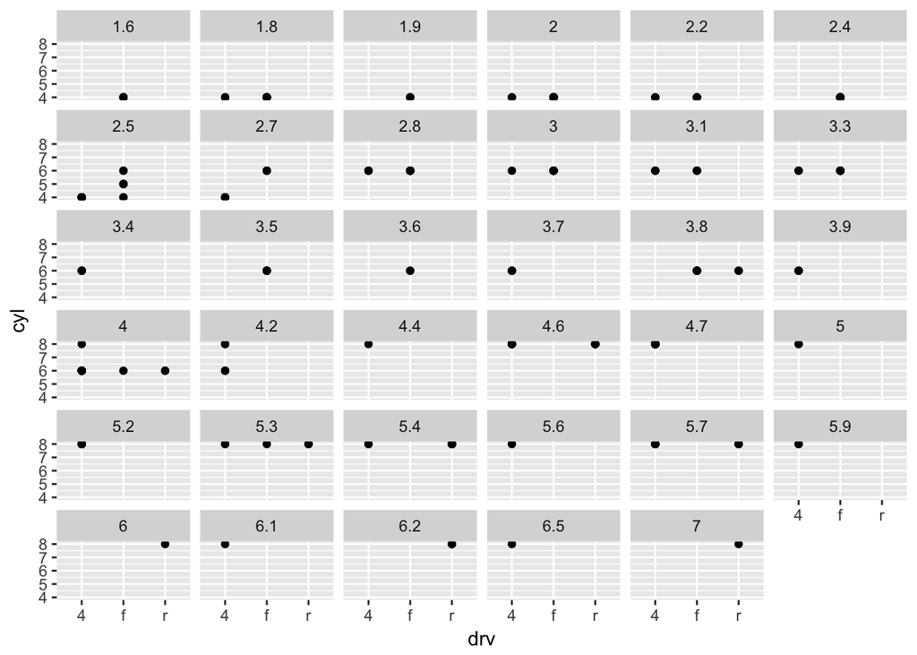

```r
ggplot(data = mpg) +
  geom_point(mapping = aes(x = drv, y = cyl)) +
  facet_wrap(~displ)
```

2. R scatterplots on seperate facets by different combinations of two variables drv and cyl. It tells us if there are observations in certain combinations.

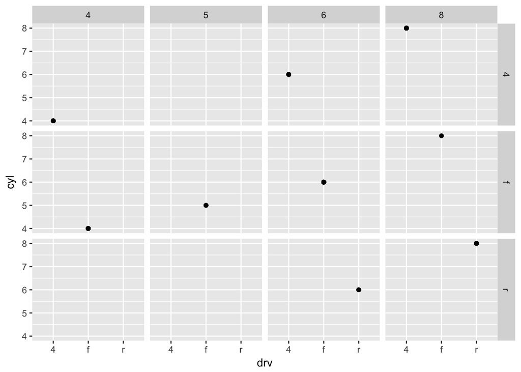

```r
ggplot(data = mpg) +
  geom_point(mapping = aes(x = drv, y = cyl)) +
  facet_grid(drv ~ cyl)
```

3. facet_grid(drv ~ .) forms a matrix of panels defined by a row facetting variable drv with no dimension on the right-hand side, which is the column facet. It forms a three-by-one grid.

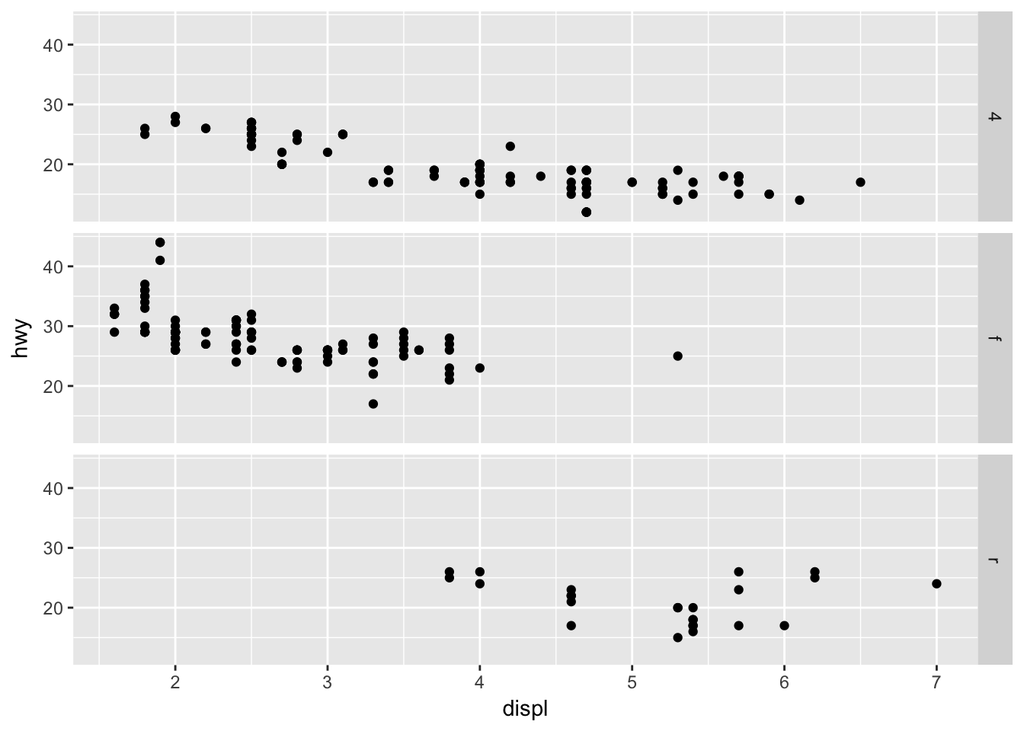

```r
ggplot(data = mpg) +
  geom_point(mapping = aes(x = displ, y = hwy)) +
  facet_grid(drv ~ .)
```

facet_grid(. ~ cyl) forms a matrix of panels defined by a column facetting variable cyl with no dimension on the left-hand side, which is the row facet. It forms a one-by-four grid.

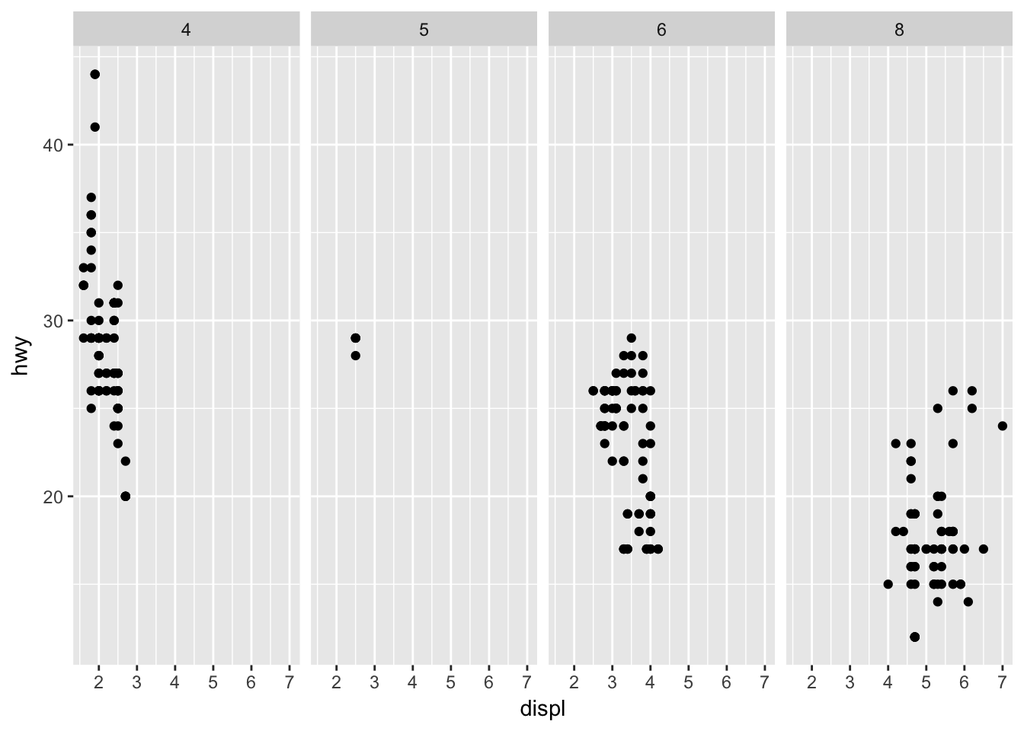

```r
ggplot(data = mpg) +
  geom_point(mapping = aes(x = displ, y = hwy)) +
  facet_grid(. ~ cyl)
```

4. By using faceting, we can observe the trends and distribution of data points within each facet seperately. However, by seperating them into individual facets, it’s hard to observe the overall trends. With large data sets, data points might overlap, and as a result, color aethetic might not work well.

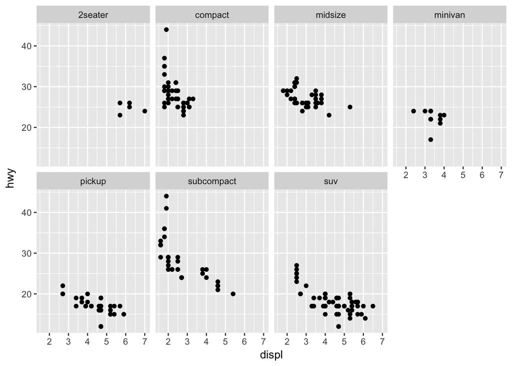

```r
ggplot(data = mpg) +
  geom_point(mapping = aes(x = displ, y = hwy)) +
  facet_wrap(~ class, nrow = 2)
```

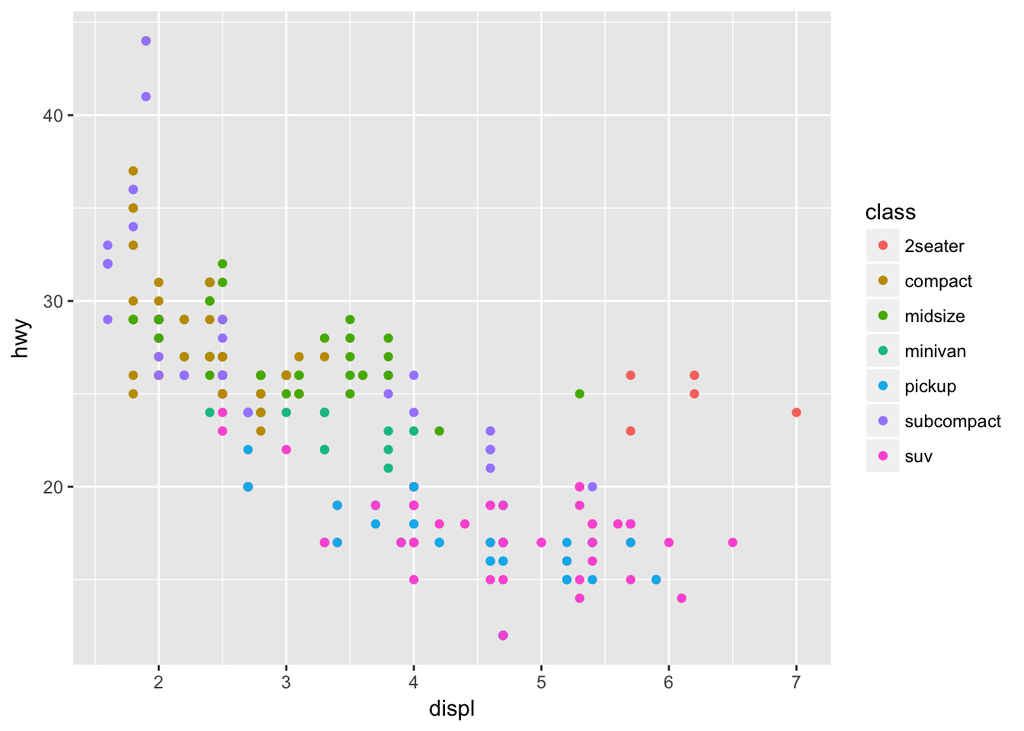

```r
ggplot(data = mpg) +
  geom_point(mapping = aes(x = displ, y = hwy, color=class))
```

5. **?nrow** returns the number of rows a facet plot has **?ncol** returns the number of columns a facet plot has **scales** determines if the scale is fixed, free, or free in one dimension **as.table** is true when facets are tablized with the highest value on the bottom-right, and false when facets are only plotted with highest values at the top-right. **drop** drops all factor levels that are used in the data if drop is true; otherwise it would keep all factor levels **dir** tells the directions. “h” stands for horizontal and “v” stands for vertical.

facet_grid( ) doesn’t have nrow and ncol argument because rows and columns are decided by certain attributes of the faceting variables.

```r
?facet_wrap
```

6. when the variables have more levels, we would prefer the plot to be shown vertically because we would have more space this way. Horizontal plot can be compressed and hard to read.